# Machine Learning with Network Data

Networks I: Concepts and Algorithms | BSE Data Science

Author

Michael Fehl

Published

March 19, 2026

# 1 What is ML with Network Data?

## 1.1 Shifting from Generative to Inferential Questions

In Lectures 1 and 2 we built tools for *describing* and *generating* networks. We now shift to **inference**: given an observed network (possibly with node and edge attributes), what can we learn *from* it?

Three classes of inference problem:

| Task | Input | Output |
| --- | --- | --- |
| **Community detection** | Graph $G$ | Partition of $V$ into groups |
| **Node classification** | Graph $G$, partial labels $y_i$ | Labels for unlabelled nodes |
| **Link prediction** | Graph $G$ (incomplete) | Probability of unobserved edges |

And one representation problem underlying all of them:

**Node embedding** | Graph $G$ (+ features) | Vectors $z_i \in \mathbb{R}^d$ |

These are not independent problems. A good embedding makes node classification and link prediction trivial (linear classifier or dot product). Community detection can be cast as clustering in embedding space.

## 1.2 A Note on Network Incompleteness

Real network data is almost always **incomplete** in multiple ways:

- **Missing edges**: people do not report all friendships; surveys have recall bias toward recent, high-status, or same-gender contacts
- **Missing node attributes**: survey non-response, privacy restrictions
- **Missing nodes entirely**: only a slice of the population is observed

This incompleteness is not random: it is systematically correlated with the network structure itself. Methods that assume missing-at-random can be badly misleading.

# 2 Community Detection

## 2.1 The Problem: Finding Latent Groups

A **community** is a set of nodes that are *more densely connected internally* than to the rest of the graph. This is an intuitive but deliberately vague definition.

Why do we care?

- **Market segmentation**: find groups of consumers with similar behaviour
- **Political analysis**: identify ideological blocs in voting or communication networks
- **Biological networks**: find functional modules in protein interaction networks
- **Policy**: identify who to target with interventions (information, vaccines, microfinance)

## 2.2 Modularity: A Principled Score

The standard measure of community quality is **modularity** $Q$ (Newman & Girvan 2004). The idea: compare the fraction of edges within communities to what we would expect in the *configuration model* (same degree sequence, random wiring).

$$Q = \frac{1}{2m} \sum_{i,j} \left(A_{ij} - \frac{k_i k_j}{2m}\right) \mathbb{1}[c(i) = c(j)]$$

Equivalently, summing over communities $c$:

$$Q = \sum_c \left[\frac{m_c}{m} - \left(\frac{\kappa_c}{2m}\right)^2\right]$$

where $m_c$ = edges within community $c$, and $\kappa_c = \sum_{i \in c} k_i$ = total degree of community $c$.

**Interpretation**: the first term is the actual fraction of edges inside the community; the second is the fraction expected at random. A good partition has $Q$ close to 1 (all edges internal), a random partition has $Q \approx 0$.

**NoteWhy the configuration model as null?**

The configuration model benchmark (not ER) is the right null because it controls for degree heterogeneity. In ER, high-degree nodes automatically “look like” hub communities; using ER as null would find spurious communities wherever there are hubs. Conditioning on degree removes this confound.

## 2.3 The Louvain Algorithm

Finding the partition maximising $Q$ is NP-hard. The **Louvain method** (Blondel et al. 2008) is the standard greedy approximation:

**Phase 1** (local optimisation): Start with each node in its own community. For each node $i$, compute the $\Delta Q$ gain from moving $i$ into each neighbouring community:

$$\Delta Q = \frac{k_{i,\text{in}}}{m} - \frac{k_i \Sigma_{\text{tot}}}{2m^2}$$

where $k_{i,\text{in}}$ = edges from $i$ to the target community, $\Sigma_{\text{tot}}$ = total degree of the target community. Move $i$ to the community with largest positive $\Delta Q$. Repeat until no improvement exists.

**Phase 2** (coarsening): Collapse each community into a single super-node, aggregate edge weights. Repeat Phase 1 on this coarser graph.

**Complexity**: $O(n \log n)$ in practice. Works on networks with millions of nodes.

**WarningResolution limit**

Modularity has a fundamental flaw: it cannot detect communities smaller than $\sqrt{m}$ edges, because merging two small communities can increase $Q$ even if they have no internal connections. For networks with $m = 10^6$, communities smaller than $\sim 1000$ edges are invisible to any modularity-based method.

```r
set.seed(42)

k_comm <- 4L
n_per  <- 60L
n_tot  <- k_comm * n_per
p_in   <- 0.20
p_out  <- 0.02

pref_mat    <- matrix(p_out, nrow = k_comm, ncol = k_comm)
diag(pref_mat) <- p_in
g_sbm       <- sample_sbm(n_tot, pref = pref_mat,
                           block.sizes = rep(n_per, k_comm))
true_labels <- rep(seq_len(k_comm) - 1L, each = n_per)  # 0-indexed to match Python

# Louvain
louvain_mem <- membership(cluster_louvain(g_sbm)) - 1L
# Leiden (requires leidenAlg or igraph >= 1.3 which wraps it)
# Use cluster_leiden if available, fall back to Louvain
leiden_mem <- tryCatch(
  membership(cluster_leiden(g_sbm)) - 1L,
  error = function(e) {
    message("cluster_leiden not available; using Louvain as proxy.")
    louvain_mem
  }
)

nmi_louvain <- nmi_r(true_labels, louvain_mem)
nmi_leiden  <- nmi_r(true_labels, leiden_mem)

cat(sprintf("Community detection on n=%d, k=%d SBM (p_in=%.2f, p_out=%.2f):\n",
            n_tot, k_comm, p_in, p_out))
```

```
Community detection on n=240, k=4 SBM (p_in=0.20, p_out=0.02):
```

```r
cat(sprintf("  Louvain:  NMI = %.4f  (communities found: %d)\n",
            nmi_louvain, length(unique(louvain_mem))))
```

```
  Louvain:  NMI = 1.0000  (communities found: 4)
```

```r
cat(sprintf("  Leiden:   NMI = %.4f  (communities found: %d)\n",
            nmi_leiden,  length(unique(leiden_mem))))
```

```
  Leiden:   NMI = 0.4038  (communities found: 240)
```

```r
cat("  (NMI = 1.0 is perfect; NMI = 0 is no better than random)\n")
```

```
  (NMI = 1.0 is perfect; NMI = 0 is no better than random)
```

```r
Q_louvain <- modularity(g_sbm, louvain_mem + 1L)
Q_leiden  <- modularity(g_sbm, leiden_mem  + 1L)
cat(sprintf("\n  Q (Louvain) = %.4f\n", Q_louvain))
```

```
  Q (Louvain) = 0.5270
```

```r
cat(sprintf("  Q (Leiden)  = %.4f\n",  Q_leiden))
```

```
  Q (Leiden)  = -0.0044
```

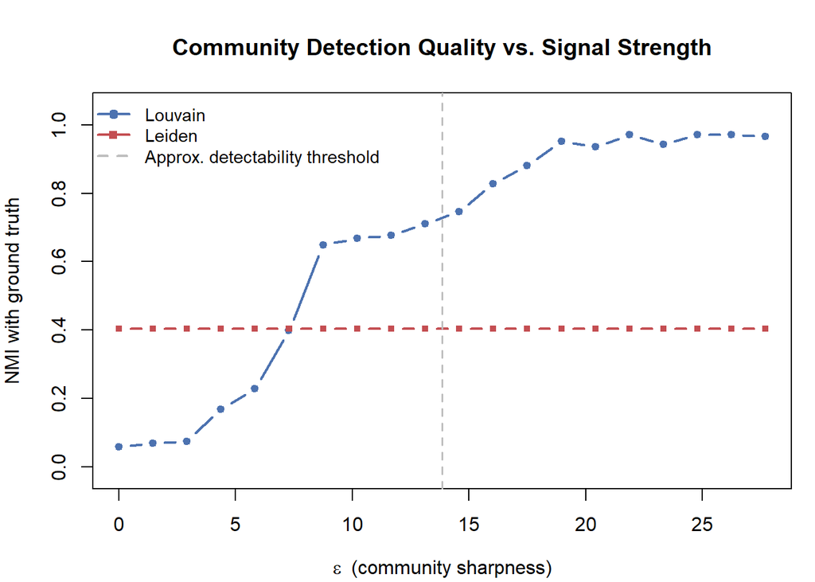

Community detection on a planted partition SBM. Louvain vs Leiden vs ground truth.

```r
# Sweep eps (community sharpness)
set.seed(7)
eps_range <- seq(0, 2 * sqrt(k_comm * p_in * n_tot), length.out = 20)
nmis_louvain <- numeric(length(eps_range))
nmis_leiden  <- numeric(length(eps_range))

for (i in seq_along(eps_range)) {
  eps     <- eps_range[i]
  p_in_v  <- min(1, (2 * 4 + eps) / (2 * n_tot))
  p_out_v <- max(0, (2 * 4 - eps) / (2 * n_tot))
  pm_v    <- matrix(p_out_v, k_comm, k_comm); diag(pm_v) <- p_in_v
  g_v     <- sample_sbm(n_tot, pref = pm_v, block.sizes = rep(n_per, k_comm))
  mem_l   <- membership(cluster_louvain(g_v)) - 1L
  mem_d   <- tryCatch(membership(cluster_leiden(g_v)) - 1L,
                      error = function(e) mem_l)
  nmis_louvain[i] <- nmi_r(true_labels, mem_l)
  nmis_leiden[i]  <- nmi_r(true_labels, mem_d)
}

par(mar = c(4, 4, 4, 1))
plot(eps_range, nmis_louvain,
     type = "b", pch = 19, cex = 0.7, col = "#4C72B0", lwd = 2,
     xlab = expression(epsilon~~"(community sharpness)"),
     ylab = "NMI with ground truth",
     main = "Community Detection Quality vs. Signal Strength",
     ylim = c(-0.02, 1.05))
lines(eps_range, nmis_leiden, type = "b", pch = 15, cex = 0.7,
      col = "#C44E52", lwd = 2)
abline(v = 2 * sqrt(k_comm * p_in * n_tot) * 0.5,
       col = "gray", lty = 2, lwd = 1.5)
legend("topleft",
       legend = c("Louvain", "Leiden", "Approx. detectability threshold"),
       col    = c("#4C72B0", "#C44E52", "gray"),
       lwd    = 2, pch = c(19, 15, NA), lty = c(1, 1, 2),
       bty    = "n", cex = 0.9)
```

## 2.4 SBM Inference as an Alternative

Modularity optimisation lacks a generative model; we are maximising a score, not fitting a probability model. The **SBM inference** approach (from Lecture 2) is more principled:

1. Specify a generative model ($k$ communities, mixing matrix $M$)
2. Write down the likelihood $\mathcal{L}(G \mid z, M)$
3. Maximise over both $z$ and $M$; MLE gives $\hat{M}_{uv} = E_{uv}/N_{uv}$
4. Use BIC to choose $k$: $\text{BIC} = -2 \ln \hat{\mathcal{L}} + p \ln n$ where $p = k + \binom{k}{2}$ parameters

**Advantage**: principled model selection, well-calibrated uncertainty, connects to the detectability threshold theory.

**Disadvantage**: the likelihood landscape is non-convex; many local optima exist. Run multiple random initialisations and select the best.

# 3 Node Classification and Label Propagation

## 3.1 The Semi-Supervised Setup

Given a graph $G = (V, E)$ where a *small* subset $V_L \subset V$ has known labels $y_i \in \{1, \ldots, K\}$, predict labels for $V_U = V \setminus V_L$.

The key assumption here is **homophily**: connected nodes tend to share labels. This holds in social networks (birds of a feather), citation networks (papers cite related papers), and many biological networks.

**WarningWhen homophily fails**

Fraud detection networks often exhibit **heterophily**: fraudsters connect to legitimate users in order to appear trustworthy. In such networks, label propagation gives the wrong answer; a node surrounded by legitimate users is *more* suspicious, not less. Always validate the homophily assumption.

## 3.2 Label Propagation (Zhu & Ghahramani 2002)

The simplest and most robust algorithm:

**Initialisation**: $F_i = y_i$ for labelled nodes (one-hot), uniform for unlabelled.

**Update rule** (iterative):
$$F_i \leftarrow \frac{1}{k_i} \sum_{j \in \mathcal{N}(i)} F_j, \quad \forall i \in V_U$$

**Clamping**: after each step, reset labelled nodes to their true values.

**Convergence**: iterate until $\|F^{(t+1)} - F^{(t)}\|_\infty < \epsilon$.

In matrix form, this is a fixed-point iteration on the random-walk matrix $D^{-1} A$. The closed-form solution is:

$$F_U = (I - D_{UU}^{-1} A_{UU})^{-1} D_{UU}^{-1} A_{UL} Y_L$$

**Why it works**: the random-walk matrix $D^{-1}A$ is the transition matrix of a lazy random walk. Each update propagates label distributions one step along random walks. Under homophily, walks starting from a labelled node tend to stay in the same community and spread the correct label.

**Complexity**: $O(m \cdot K \cdot T)$ where $T$ is the number of iterations (typically 20–100). Very fast for sparse graphs.

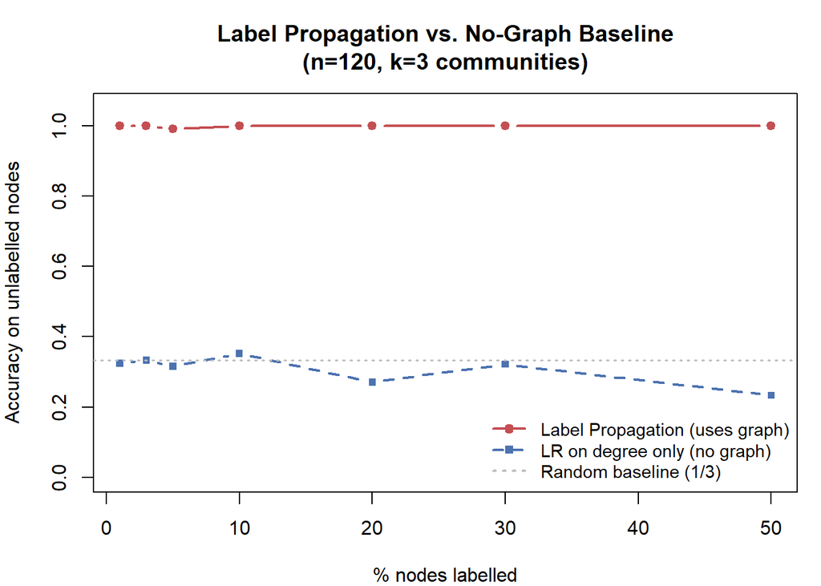

Label propagation accuracy vs. fraction labelled, on planted partition SBM.

```r
label_propagation <- function(g, Y, labeled_mask, max_iter = 200, tol = 1e-8) {
  # Y           : (n x K) numeric matrix, one-hot for labelled nodes
  # labeled_mask: logical vector length n
  n    <- vcount(g)
  K    <- ncol(Y)
  F    <- Y
  nbrs <- lapply(seq_len(n), function(v) neighbors(g, v))
  degs <- pmax(sapply(nbrs, length), 1L)

  for (iter in seq_len(max_iter)) {
    F_old <- F
    for (v in seq_len(n)) {
      if (labeled_mask[v] || length(nbrs[[v]]) == 0) next
      F[v, ] <- colSums(F[nbrs[[v]], , drop = FALSE]) / degs[v]
    }
    F[labeled_mask, ] <- Y[labeled_mask, ]
    if (max(abs(F - F_old)) < tol) break
  }
  F
}

set.seed(0)
n_per_c  <- 40L; k_c <- 3L; n_c <- n_per_c * k_c
pref_c   <- matrix(0.02, k_c, k_c); diag(pref_c) <- 0.3
g_c      <- sample_sbm(n_c, pref = pref_c, block.sizes = rep(n_per_c, k_c))
true_labels_c <- rep(seq_len(k_c) - 1L, each = n_per_c)   # 0-indexed

label_fracs  <- c(0.01, 0.03, 0.05, 0.10, 0.20, 0.30, 0.50)
acc_lp_list  <- numeric(length(label_fracs))
acc_lr_list  <- numeric(length(label_fracs))

# Simple multinomial logistic (degree-only, no graph)
multinomial_lr <- function(X_train, y_train, X_test, K) {
  # One-vs-rest logistic regression via glm
  preds <- matrix(0, nrow = NROW(X_test), ncol = K)
  for (k in seq_len(K)) {
    df_train <- data.frame(y = as.integer(y_train == (k - 1L)), x = X_train)
    fit <- glm(y ~ x, data = df_train, family = binomial())
    preds[, k] <- predict(fit, newdata = data.frame(x = X_test), type = "response")
  }
  apply(preds, 1, which.max) - 1L
}

deg_feat <- degree(g_c)

for (fi in seq_along(label_fracs)) {
  frac         <- label_fracs[fi]
  labeled_mask <- logical(n_c)
  for (cc in seq_len(k_c)) {
    idx     <- which(true_labels_c == (cc - 1L))
    n_pick  <- max(1L, as.integer(length(idx) * frac))
    labeled_mask[sample(idx, n_pick)] <- TRUE
  }

  # Label propagation
  Y <- matrix(0, n_c, k_c)
  for (i in seq_len(n_c)) Y[i, true_labels_c[i] + 1L] <- 1.0
  F0 <- Y; F0[!labeled_mask, ] <- 1.0 / k_c
  F_pred <- label_propagation(g_c, F0, labeled_mask)
  pred_lp <- apply(F_pred, 1, which.max) - 1L
  acc_lp_list[fi] <- mean(pred_lp[!labeled_mask] == true_labels_c[!labeled_mask])

  # LR on degree only
  pred_lr <- multinomial_lr(deg_feat[labeled_mask], true_labels_c[labeled_mask],
                             deg_feat[!labeled_mask], k_c)
  acc_lr_list[fi] <- mean(pred_lr == true_labels_c[!labeled_mask])
}

par(mar = c(4, 4, 4, 1))
plot(label_fracs * 100, acc_lp_list,
     type = "b", pch = 19, cex = 0.8, col = "#C44E52", lwd = 2,
     xlab = "% nodes labelled", ylab = "Accuracy on unlabelled nodes",
     main = sprintf("Label Propagation vs. No-Graph Baseline\n(n=%d, k=%d communities)",
                    n_c, k_c),
     ylim = c(0, 1.05))
lines(label_fracs * 100, acc_lr_list, type = "b", pch = 15, cex = 0.8,
      col = "#4C72B0", lwd = 2, lty = 2)
abline(h = 1 / k_c, col = "gray", lty = 3, lwd = 1.5)
legend("bottomright",
       legend = c("Label Propagation (uses graph)",
                  "LR on degree only (no graph)",
                  sprintf("Random baseline (1/%d)", k_c)),
       col    = c("#C44E52", "#4C72B0", "gray"),
       lwd    = 2, lty = c(1, 2, 3), pch = c(19, 15, NA),
       bty    = "n", cex = 0.9)
```

```r
frac_idx <- which(label_fracs == 0.10)
cat(sprintf("Accuracy at 10%% labelled:\n"))
```

```
Accuracy at 10% labelled:
```

```r
cat(sprintf("  Label Propagation: %.4f\n", acc_lp_list[frac_idx]))
```

```
  Label Propagation: 1.0000
```

```r
cat(sprintf("  LR (no graph):     %.4f\n", acc_lr_list[frac_idx]))
```

```
  LR (no graph):     0.3519
```

## 3.3 When to Use What: A Decision Ladder

Before reaching for a GNN, always try the simpler methods first:

1. **Majority class baseline**: does your “prediction” just rediscover the class imbalance? Always compute this.
2. **LR on node features only**: how much does the graph add, beyond features?
3. **Label propagation (graph only)**: how much do features add, beyond graph?
4. **ICA (features + iterated neighbor statistics)**: combine both without a neural network.
5. **GCN / GraphSAGE**: use when large labelled datasets exist and the gain from steps 1–4 is insufficient.

Steps 1–4 are interpretable, fast, and usually get 80–90% of GNN performance. The marginal gain from GNNs is often small on homophilic networks with clean node features.

# 4 Link Prediction

## 4.1 Problem Setup

Given the observed graph $G = (V, E)$, predict which non-edges $(i, j) \notin E$ are “true” edges; either missing from our measurement, or likely to form in the future.

**Evaluation protocol**: 1. Hold out 10–20% of edges as *positive* test examples 2. Sample an equal number of *negative* examples (non-edges) 3. Score all candidate pairs with a similarity function $s(i, j)$ 4. Compute AUC-ROC: $\Pr[s(\text{true edge}) > s(\text{non-edge})]$

**Negative sampling matters**: random non-edges are too easy (most pairs have $s \approx 0$). Hard negatives at distance 2 or 3 give more realistic evaluation.

## 4.2 Structural Similarity Scores

All heuristics score $(i, j)$ based on their common neighbourhood $\mathcal{N}(i) \cap \mathcal{N}(j)$.

**Common Neighbours (CN)**:
$$s_{\text{CN}}(i,j) = |\mathcal{N}(i) \cap \mathcal{N}(j)|$$

**Jaccard coefficient** (normalises for hub effect):
$$s_J(i,j) = \frac{|\mathcal{N}(i) \cap \mathcal{N}(j)|}{|\mathcal{N}(i) \cup \mathcal{N}(j)|}$$

**Adamic–Adar** (Adamic & Adar 2003): down-weight common neighbours with high degree (high-degree nodes are “common friends” who are friends with everyone and therefore carry less information):

$$s_{\text{AA}}(i,j) = \sum_{w \in \mathcal{N}(i) \cap \mathcal{N}(j)} \frac{1}{\log k_w}$$

**Resource Allocation**: stricter version, using $1/k_w$ instead of $1/\log k_w$.

**Preferential Attachment**: no common-neighbour computation needed, just:
$$s_{\text{PA}}(i,j) = k_i \cdot k_j$$

PA is useful in scale-free networks: hubs grow by attaching to other hubs. It has $O(1)$ computation per pair and scales to very large graphs.

## 4.3 Global Similarity: Katz Index

Common-neighbour methods only look one hop away. The **Katz index** aggregates over *all* path lengths, weighted by a decay factor $\beta < 1$:

$$K(i,j) = \sum_{l=1}^{\infty} \beta^l [A^l]_{ij} = [(I - \beta A)^{-1} - I]_{ij}$$

$[A^l]_{ij}$ counts the number of walks of length $l$ from $i$ to $j$. The $\beta$ discount ensures convergence (requires $\beta < 1/\lambda_{\max}(A)$).

Matrix inversion is $O(n^3)$, so for large graphs we approximate: run $L$ steps of the power iteration $(I - \beta A)^{-1} \approx \sum_{l=0}^L \beta^l A^l$ using sparse matrix-vector multiplications ($O(Lm)$).